# Problem Set 1

MinAh Kim

2023-04-02

```r
#########################################################
## 0) Import CSV file & packages

# remove environment list
rm(list=ls())

# import library
library(tidyverse)
library(miceadds)
```

```r
library(ggplot2)

# import data set
df <- read.csv("rct_problem_set.csv")
```

```r
# explore the data set
head(df)
```

```
##   school_id grade treatcluster treatcluster_group person_id age female
## 1         1     1            1                  3      7021   5      0
## 2         1     2            1                  4       296   7      1
## 3         1     3            1                  5      3559   8      1
## 4         1     4            0                  0       908  10      1
## 5         1     5            1                  1     14713   9      0
## 6         2     1            1                  4      1657   7      1
##   treatment attend math read
## 1         0      1  471  604
## 2         1      1  721  766
## 3         1      1  658  749
## 4         0      1  576  473
## 5         0      1  563  574
## 6         1      1  723  742
```

```r
dim_df <- dim(df)
```

### Q1 Start by regressing the outcome of interest, attend, on the treatment indicator. What are your preliminary results? How does accounting for the clustered randomization design affect your preliminary results?

```r
# First, I will identify each cluster by making a variable
df_regress <- df %>%
                mutate(cluster_id = group_indices(df, .dots = c("school_id", "grade")))
# linear regression with the outcome (attend) and the individual treatment status (treatment)
notclustered = lm(attend ~ treatment, data = df_regress)

# linear regression with the outcome (attend) and the treatment status by cluster
clustered = lm.cluster(attend ~ treatment, data = df_regress, cluster = "cluster_id")
```

Let’s first check the result of the regression on attendance and treatment status.

```r
# summary of regressing attendance on treatment
summary(notclustered)
```

```
##
## Call:
## lm(formula = attend ~ treatment, data = df_regress)
##
## Residuals:
##      Min       1Q   Median       3Q      Max
## -0.99035  0.00965  0.06393  0.06393  0.06393
##
## Coefficients:
##              Estimate Std. Error t value Pr(>|t|)
## (Intercept) 0.9360750  0.0002993  3128.0   <2e-16 ***
## treatment   0.0542734  0.0005555    97.7   <2e-16 ***
## ---
## Signif. codes:  0 '***' 0.001 '**' 0.01 '*' 0.05 '.' 0.1 ' ' 1
##
## Residual standard error: 0.2127 on 711813 degrees of freedom
##   (105472 observations deleted due to missingness)
## Multiple R-squared:  0.01323,    Adjusted R-squared:  0.01323
## F-statistic:  9546 on 1 and 711813 DF,  p-value: < 2.2e-16
```

Based on the initial regression, we found statistically significant relationship between the treatment status and attendance. Based on the t-value, we learn that the control and the treatment are significantly different from each other. The low p value also shows that this difference is very unlikely to happen by chance.

```r
# summary of regressing attendance on treatment with clusters
summary(clustered)
```

```
## R^2= 0.01323
##
##               Estimate   Std. Error   t value Pr(>|t|)
## (Intercept) 0.93607499 0.0004032584 2321.2783        0
## treatment   0.05427341 0.0004557675  119.0813        0
```

When we recognize the cluster, we can notice that the coefficient of the regression does not change. The t value and the p value also demonstrate that the regression still shows statistical significance.

### Q2 Check for balance between the treatment and control observations based on age, gender, math scores and reading scores. Are these observables balanced across the treatment and control groups?

```r
## let's check balance based on age first!
# We run a regression between treatment status and age to see if there is any significant pattern
age_balance = lm.cluster(age ~ treatment, data = df_regress, cluster = "cluster_id")
summary(age_balance)
```

```
## R^2= 0
##
##                Estimate Std. Error      t value  Pr(>|t|)
## (Intercept) 7.999596543 0.02834202 282.25219610 0.0000000
## treatment   0.003163687 0.04341158   0.07287658 0.9419043
```

Let’s check the balance based on other attributes by repeating the same method.

```r
## Checking the balance based on gender (more precisely, if the individual is female or not)
# We run a regression between treatment status and the female variable
female_balance = lm.cluster(female ~ treatment, data = df_regress, cluster = "cluster_id")
summary(female_balance)
```

```
## R^2= 0
##
##                Estimate   Std. Error    t value   Pr(>|t|)
## (Intercept)  0.57151355 0.0006688208 854.509285 0.00000000
## treatment   -0.00214326 0.0012164420  -1.761909 0.07808462
```

Now, let’s check the balance based on the math score.

```r
# Checking the balance based on math score
math_balance = lm.cluster(math ~ treatment, data = df_regress, cluster = "cluster_id")
summary(math_balance)
```

```
## R^2= 0
##
##                Estimate Std. Error      t value Pr(>|t|)
## (Intercept) 657.1714294  0.1194312 5502.5100667 0.000000
## treatment     0.1287531  0.2197723    0.5858475 0.557978
```

After running the regression, we do not find any statistical significance between the math score and the treatment status. The t value is low and the p value also tells that this result is more than 20% likely to be caused by random chance. As a result, we cannot infer that the distribution of math score differs based on the treatment and the control group.

```r
reading_balance = lm.cluster(read ~ treatment, data = df_regress, cluster = "cluster_id")
summary(reading_balance)
```

```
## R^2= 0
##
##                Estimate Std. Error      t value  Pr(>|t|)
## (Intercept) 604.4447454  0.1500886 4027.2528425 0.0000000
## treatment     0.1256152  0.2925068    0.4294437 0.6676004
```

We are finally checking the balance on reading score between the treatment and the control group. Again, the regression does not show any statistical significance between the two group. Hence, we can continue to assume that the treatment and control is balance based on the reading score.

### Q3 Check if there are observations that are missing outcome data. If there are any, does this attrition appear random or not?

This question is asking us about attrition, or the participants’ drop-out after the randomization. The dataset represents attrition by using the NA value in the ‘attend’ column. We will create a column “attrition” to record the missing outcome value as 1 and else as 0.

In order to check the randomness of the attrition, I will use regression to reveal any meaningful difference.

```r
# Let's create a column for attrition (1 when the attendance is NA)
df_regress$attrition <- ifelse(is.na(df_regress$attend), 1, 0)

attrition_randomness = lm(attrition ~ treatment, data = df_regress)
summary(attrition_randomness)
```

```
##
## Call:
## lm(formula = attrition ~ treatment, data = df_regress)
##
## Residuals:
##     Min      1Q  Median      3Q     Max
## -0.1294 -0.1294 -0.1289 -0.1289  0.8711
##
## Coefficients:
##              Estimate Std. Error t value Pr(>|t|)
## (Intercept) 0.1289182  0.0004402 292.850   <2e-16 ***
## treatment   0.0004587  0.0008170   0.561    0.575
## ---
## Signif. codes:  0 '***' 0.001 '**' 0.01 '*' 0.05 '.' 0.1 ' ' 1
##
## Residual standard error: 0.3353 on 817285 degrees of freedom
## Multiple R-squared:  3.857e-07,  Adjusted R-squared:  -8.379e-07
## F-statistic: 0.3152 on 1 and 817285 DF,  p-value: 0.5745
```

The regression has a low t value and the high p value that would not qualify to be statistically significant. Therefore, we can continue assuming that the attrition is random.

### Q4 Implement a permutation test to assess the credibility of your estimated treatment effect. Include a plot of the distribution of estimates from your permutation samples and mark your estimate based on the actual data in this distribution. What fraction of estimates from your permutation test have higher estimated treatment effects that the estimate based on the actual data?

The permutation test checks if the difference between the control and the treatment is not a product of random chance. We first randomly assigns the treatment status and calculate the result like how we did it in Question 1. Then, we will find the distribution of the results and then compare the likelihood that our result came out by chance.

```r
## 1. Randomly assign the treatment status
# First let's check the distribution of the assignment by checking the distribution of the treatcluster variable
num_cluster <- length(unique(df_regress$cluster_id))
num_treat <- length(unique(df_regress$cluster_id[df_regress$treatcluster == 1]))
num_control <- num_cluster - num_treat

cat(paste("The number of clusters originally assigned to a control group:", num_control, "\nThe number of clusters originally assigned to a treatment group:", num_treat))
```

```
## The number of clusters originally assigned to a control group: 992
## The number of clusters originally assigned to a treatment group: 953
```

```r
# matrix to save the coefficients of each trial
reps = num_cluster
CoefMatrix  = matrix(NA, reps, 1)

# loop to randomly assign treatment status
for (i in c(1:reps)) {
  # choose the cluster to randomly assign treatment status
  random_cluster_treatment <- sample(c(1:num_cluster), num_treat, replace = FALSE)

  # assign the treatment status and save it in random_treatment
  df_regress<- df_regress %>%
    mutate(random_treatment = ifelse(cluster_id %in% random_cluster_treatment, 1, 0))

  #run a regression
  random_regression = lm.cluster(df_regress, attend ~ random_treatment, cluster = "cluster_id")

  #save it in a matrix
  CoefMatrix[i, 1] <- summary(random_regression)[2,1]

}
```

```r
# plot the result
df_graph = data.frame(coefficient = CoefMatrix)
original_coeff = summary(clustered)[2,1]
```

```
## R^2= 0.01323
##
##               Estimate   Std. Error   t value Pr(>|t|)
## (Intercept) 0.93607499 0.0004032584 2321.2783        0
## treatment   0.05427341 0.0004557675  119.0813        0
```

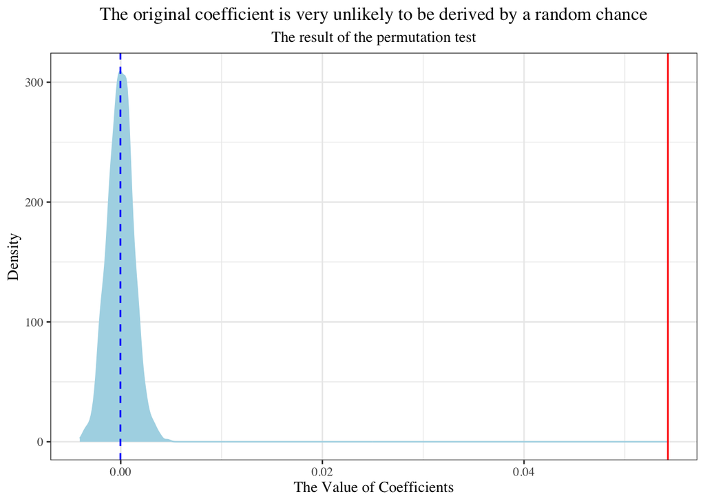

```r
ggplot(data = df_graph, aes(x= coefficient)) +
  theme_bw()+
  geom_density(fill = "lightblue", color ="lightblue") +
  geom_vline(aes(xintercept = mean(coefficient)), linetype = "dashed", size = 0.6, color = "blue")+
  annotate("text", x=mean(df$coefficient), y=20, label="Mean", angle=90)+
  geom_vline(aes(xintercept = original_coeff), linetype = "solid", size = 0.6, color = "red") +
  annotate("text", x=mean(df$coefficient), y=20, label="Estimate based on actual data", angle=90)+
  labs(
    title = "The original coefficient is very unlikely to be derived by a random chance",
    subtitle = "The result of the permutation test",
    x = "The Value of Coefficients",
    y = "Density"
  )+
  theme(text = element_text(family = "Times"),
        plot.title = element_text(hjust = 0.5),
        plot.subtitle = element_text(hjust = 0.5)
        )
```

```r
df_graph <- df_graph %>%
  add_row(data.frame(coefficient =c(original_coeff))) %>%
  arrange(coefficient)

print(paste("Only ", (dim(df_graph)[1] - mean(which(df_graph$coefficient == original_coeff)))/dim(df_graph)[1]*100, "% of the estimates from the permutation have higher estimatedd treatment effects than that based on the actual data"))
```

```
## [1] "Only  0 % of the estimates from the permutation have higher estimatedd treatment effects than that based on the actual data"
```

### Q5 Now suppose that you learn that, in addition to being clustered at the school and grade level, you learn that the randomization varied treatment intensity within treatment clusters. The treatcluster variable captures which school-grades were assigned to treatment and which were assigned to control. Within the treated clusters, the clusters were randomly assigned to groups 1, 2, 3, 4 and 5, with the fraction of observations within these clusters assigned to treatment varying from 20%, 40%, 60%, 80% and 100% respectively.

#### a. To test for peer effects from the treatment, create two sets of indicator variables: (1) indicator variables for treatment observations within each treated cluster group and (2) indicator variables for observations within each treated cluster group. Regress the attend outcome variable on these indicators.

```r
# create the indicator variables for treatment observations within each treated cluster group and the observations within each treated cluster group.
# I call the indicator variables direct_treat and indirect_treat for the directly treated and indirectly treated variable

df_regress <- df_regress %>%
  mutate(
    direct_treat = ifelse((treatcluster == 1)& (treatment == 1), 1, 0),
    indirect_treat = ifelse((treatcluster == 1) & (treatment == 0), 1, 0)
  )

# Regress the attend outcome variable on these indicators.
peer_effect = lm.cluster(attend ~ direct_treat + indirect_treat, data = df_regress, cluster = "cluster_id")

summary(peer_effect)
```

```
## R^2= 0.01467
##
##                  Estimate   Std. Error    t value      Pr(>|t|)
## (Intercept)    0.93013018 0.0004083765 2277.62908  0.000000e+00
## direct_treat   0.06021822 0.0004635195  129.91519  0.000000e+00
## indirect_treat 0.02160174 0.0007853383   27.50629 1.476406e-166
```

#### b. Plot the coefficients on the direct treatment effects (y-axis) against the fraction treated (x-axis). How do the direct treatment effects vary with the fraction treated?

```r
## Let's run the separate regression for all five groups
# For Group 1 (Treatment for 20%)
df_regress_1 <- df_regress %>%
  filter((treatcluster_group == 1)|(treatcluster_group == 0))

group_1_reg = lm.cluster(attend ~ direct_treat + indirect_treat, data = df_regress_1, cluster = "cluster_id")

summary(group_1_reg)
```

```
## R^2= 0.00188
##
##                  Estimate   Std. Error    t value     Pr(>|t|)
## (Intercept)    0.93013018 0.0004084457 2277.24309 0.000000e+00
## direct_treat   0.05970209 0.0009483756   62.95195 0.000000e+00
## indirect_treat 0.01164284 0.0010599101   10.98474 4.525451e-28
```

```r
# For Group 2 (Treatment for 40%)
df_regress_2 <- df_regress %>%
  filter((treatcluster_group == 2)|(treatcluster_group == 0))

group_2_reg = lm.cluster(attend ~ direct_treat + indirect_treat, data = df_regress_2, cluster = "cluster_id")

summary(group_2_reg)
```

```
## R^2= 0.00401
##
##                  Estimate   Std. Error    t value     Pr(>|t|)
## (Intercept)    0.93013018 0.0004084445 2277.24968 0.000000e+00
## direct_treat   0.06079481 0.0006755969   89.98682 0.000000e+00
## indirect_treat 0.02075414 0.0011870382   17.48397 1.898044e-68
```

```r
# For Group 3 (Treatment for 60%)
df_regress_3 <- df_regress %>%
  filter((treatcluster_group == 3)|(treatcluster_group == 0))

group_3_reg = lm.cluster(attend ~ direct_treat + indirect_treat, data = df_regress_3, cluster = "cluster_id")

summary(group_3_reg)
```

```
## R^2= 0.00644
##
##                  Estimate   Std. Error    t value      Pr(>|t|)
## (Intercept)    0.93013018 0.0004084419 2277.26420  0.000000e+00
## direct_treat   0.06040734 0.0005784800  104.42424  0.000000e+00
## indirect_treat 0.03078014 0.0011752897   26.18941 3.508407e-151
```

```r
# For Group 4 (Treatment for 80%)
df_regress_4 <- df_regress %>%
  filter((treatcluster_group == 4)|(treatcluster_group == 0))

group_4_reg = lm.cluster(attend ~ direct_treat + indirect_treat, data = df_regress_4, cluster = "cluster_id")

summary(group_4_reg)
```

```
## R^2= 0.00803
##
##                  Estimate   Std. Error    t value     Pr(>|t|)
## (Intercept)    0.93013018 0.0004084422 2277.26261  0.00000e+00
## direct_treat   0.06005789 0.0005846936  102.71687  0.00000e+00
## indirect_treat 0.04060054 0.0013406343   30.28458 1.82997e-201
```

```r
# For Group 5 (Treatment for 100%)
df_regress_5 <- df_regress %>%
  filter((treatcluster_group == 5)|(treatcluster_group == 0))

group_5_reg = lm.cluster(attend ~ direct_treat + indirect_treat, data = df_regress_5, cluster = "cluster_id")

summary(group_5_reg)
```

```
## R^2= 0.00758
##
##                Estimate   Std. Error   t value Pr(>|t|)
## (Intercept)  0.93013018 0.0004084483 2277.2289        0
## direct_treat 0.06008697 0.0006054731   99.2397        0
```

```r
# Create a dataframe with each group and the estimated direct_treatment effect
peer_effect_graph <- data.frame (
  fraction_treated = c(0.2, 0.4, 0.6, 0.8, 1.0),
  direct_treatment = c(summary(group_1_reg) [2,1], summary(group_2_reg) [2,1], summary(group_3_reg) [2,1], summary(group_4_reg) [2,1], summary(group_5_reg) [2,1]),
  indirect_treatment = c(summary(group_1_reg) [3,1], summary(group_2_reg) [3,1], summary(group_3_reg) [3,1], summary(group_4_reg) [3,1], NA)
)
```

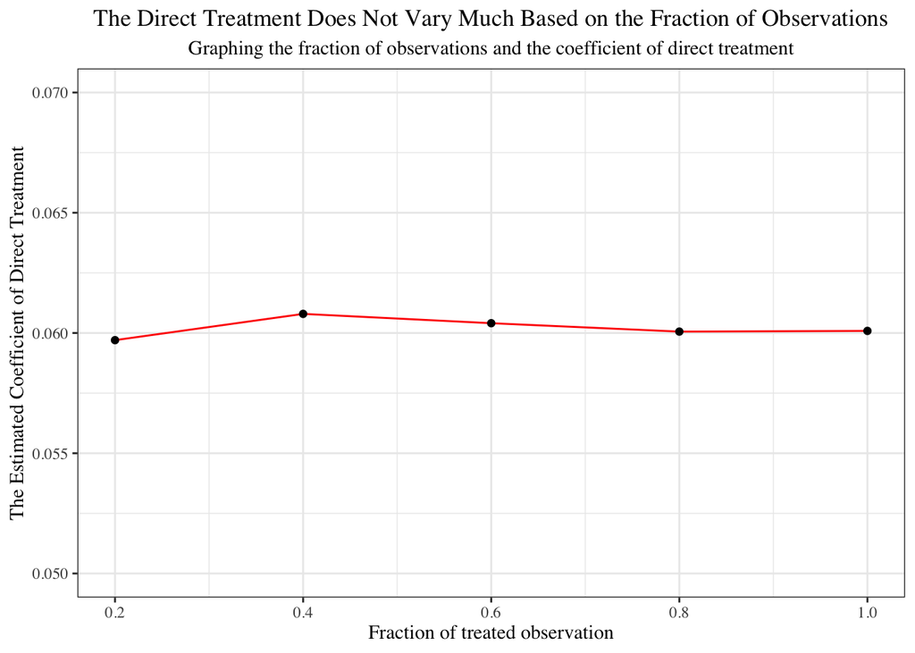

```r
ggplot(data = peer_effect_graph, aes(x = fraction_treated, y = direct_treatment)) +
  theme_bw()+
  geom_line(color = "red")+
  geom_point()+
  labs(
    title = "The Direct Treatment Does Not Vary Much Based on the Fraction of Observations",
    subtitle = "Graphing the fraction of observations and the coefficient of direct treatment",
    x = "Fraction of treated observation",
    y = "The Estimated Coefficient of Direct Treatment"
  ) +
  ylim(0.05, 0.07) +
  theme(text = element_text(family = "Times"),
        plot.title = element_text(hjust = 0.5),
        plot.subtitle = element_text(hjust = 0.5)
        )
```

From the graph, we can check that the direct treatment effects varies only slightly. Notice that the range of the y axis is only 0.02 apart. Even the range is twice smaller than the graph of the indirect treatment effect below, the change is significantly more subtle.

#### c. Plot the coefficients on the indirect treatment effects (y-axis) against the fraction treated (x-axis). How do the indirect treatment effects vary with the fraction treated? Overall, what do you conclude about possible peer effects or spillovers from the treatment?

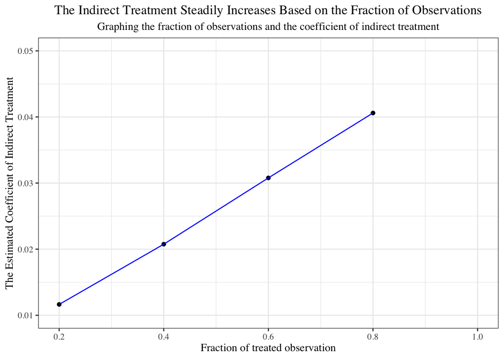

```r
ggplot(data = peer_effect_graph, aes(x = fraction_treated, y = indirect_treatment)) +
  theme_bw()+
  geom_point()+
  geom_line(color = "blue") +
  labs(
    title = "The Indirect Treatment Steadily Increases Based on the Fraction of Observations",
    subtitle = "Graphing the fraction of observations and the coefficient of indirect treatment",
    x = "Fraction of treated observation",
    y = "The Estimated Coefficient of Indirect Treatment"
  ) +
  ylim(0.01, 0.05) +
  theme(text = element_text(family = "Times"),
        plot.title = element_text(hjust = 0.5),
        plot.subtitle = element_text(hjust = 0.5)
        )
```

Unlike the coefficient of the direct treatment, the coefficient of the indirect treatment increases proportionally to the fraction of the treated observations increases. From this result, we can check that the degree of spillovers effect is greater as more people are treated in the cluster.